# Regular Expressions in R

October 8, 2018

## What are Regular Expressions?

- Regular expressions can be thought of as a combination of literals and *metacharacters*
- To draw an analogy with natural language, think of literal text forming the words of this language, and the metacharacters defining its grammar
- Regular expressions have a rich set of metacharacters

## Primary Metacharacters

The world of regular expressions is large, but there are few key metacharacters that get used often.

- Literals
- Beginning/End of line
- Character classes
- Repetition
- Parenthesized subexpression

### Literals

Literals are just sequences of characters. They have no special meaning and are interpreted by R *literally*.

The word “brother” is a literal

```
"My brother also was killed."

fortune of a cursed elder brother, whom God confound. Jealousy, discord,

"What, is it you, reverend Father? You, the brother of the fair

brother, and cut my mother in pieces. A tall Bulgarian, six feet high,

brother, his saviour.
```

So is “Brother” (but not the same!).

```
journeying, the Holy Brotherhood entered the house; my lord the
```

### Beginning/End of Line

- `^` indicates match at the **beginning** of a line
- `$` indicates match at the **end** of a line

`^The`

```
The lady then put a plump hand out from the bed, and Candide bathed it

The old woman spoke thus to Cunegonde:

The good old man smiled.

The skipper asked ten thousand piastres. Candide did not hesitate.

The Baron's lady weighed about three hundred and fifty pounds, and was
```

`the$`

```
arms. My dear Martin, yet once more Pangloss was right: all is for the

seen any one so beautiful as I, and that he never so much regretted the

the weak execrate the powerful, before whom they cringe; and the

plays with her is yet worse; and the play is still worse than the

    II. What became of Candide among the
```

### Character Classes

The square brackets `[` and `]` indicate classes of characters to search for.

`[a-z]`

```
may die of joy in her company."

"The Aga, who was a very gallant man, took his whole seraglio with him,

thousand times worse; the coolness of the magistrate and of the skipper
```

`[A-Z]`

```
"My name is Ivan. I was once Emperor of all the Russias, but was

"'My mission is done,' said this honest eunuch; 'I go to embark for

dreamed of Pangloss at every adventure told to him.
```

`[0-9]`

```
1.D.  The copyright laws of the place where you are located also govern

the real fact is I am a Manichean."[21]

[19] P. 78. The first English translator curiously gives "a tourene of
```

`[Tt]he`

```
volumes of theology, you may well imagine that neither I nor any one

black eunuchs and twenty soldiers. The Turks killed prodigious numbers

the harbour which could be sent to Buenos Ayres. The person to whom they
```

You can now combine character classes with begninning/end of line markers.

`^[Tt]he`

```
the family of my lady Baroness, and the fair Cunegonde. I swear to you

the miseries of poverty and slavery, had been ravished almost every day,

The conversation was long: it turned chiefly on their form of
```

### Matching Anything

`9.1`

```
Fairbanks, AK, 99712., but its volunteers and employees are scattered

[25] P. 109. Élie-Catherine Fréron was a French critic (1719-1776) who

[26] P. 111. Gabriel Gauchat (1709-1779), French ecclesiastical writer,
```

### Repetition

- The `+` is used to indicate “repeat the immediately preceding symbol 1 or more times”
- The `*` is used to indicate “repeat the immediately preceding symbol 0 or more times”
- `{}` can be used to indicate a range of repetition

`[0-9]+`

```
    | Notes [p. 170]; spelt Robek in the text [p. 53]) have      |

Release Date: November 27, 2006 [EBook #19942]

voluntary death, first printed in 1735.
```

`2[0-9]*`

```
[27] P. 112. Nicholas Charles Joseph Trublet (1697-1770) was a French

    | Page 172: rougish amended to roguish; crows amended to     |

[26] P. 111. Gabriel Gauchat (1709-1779), French ecclesiastical writer,
```

`[0-9]{4,6}`

```
uninteresting. Achmet III. (_b._ 1673, _d._ 1739) was dethroned in 1730.

Release Date: November 27, 2006 [EBook #19942]

Christian rites. In 1730 the "honours of sepulture" were refused to
```

`he .* good`

```
surprised at what he heard. Martin found there was a good deal of reason

Cacambo, and he loved his master, because his master was a very good

wish that he were here. Certainly, if all things are good, it is in El
```

### Parenthesized Subexpression

- `()` can be used to “capture” subexpressions

`([0-9]+)\1`

```
***** This file should be named 19942-8.txt or 19942-8.zip *****

Release Date: November 27, 2006 [EBook #19942]

[27] P. 112. Nicholas Charles Joseph Trublet (1697-1770) was a French
```

`\((.*)\)`

```
     you in writing (or by e-mail) within 30 days of receipt that s/he

skipper (were he even to rob him like the Surinam captain) to conduct

[35] P. 149. François Leopold Ragotsky (1676-1735).
```

## Regular Expression Functions

The primary R functions for dealing with regular expressions are

- `grep`, `grepl`: Search for matches of a regular expression/pattern in a character vector; either return the indices into the character vector that match, the strings that happen to match, or a TRUE/FALSE vector indicating which elements match
- `regexpr`, `gregexpr: Search a character vector for regular expression matches and return the indices of the string where the match begins and the length of the match
- `sub`, `gsub`: Search a character vector for regular expression matches and replace that match with another string
- `regexec`: Easier to explain through demonstration.

### grep

```r
library(readr)
commit_log <- read_lines("../data/commit_logs_strip.txt.bz2")
head(commit_log)
```

```
[1] "commit 7f6ef08e80191712a5eb0d75c42931466e7bbe73"
[2] "Author: ZchMr <zc@.>"
[3] "Date:   Wed Oct 1 16:55:12 2014 -0400"
[4] ""
[5] "    date changes to pages/tickets"
[6] ""
```

How many commits are there?

```r
g <- grep("^commit", commit_log)
head(g)
```

```
[1]   1  64 179 208 246 275
```

```r
length(g)
```

```
[1] 2384
```

Sometimes you want `grep()` to return the value instead of the index

```r
g <- grep("^commit", commit_log, value = TRUE)
head(g)
```

```
[1] "commit 7f6ef08e80191712a5eb0d75c42931466e7bbe73"
[2] "commit 6fe5d43383d50c698993c9b46b33f08f4897c70f"
[3] "commit f24bed325a5a5a3989187edf704410d63e055efb"
[4] "commit 8b7272dff8ab78947cfcdc173673efccf43ed22a"
[5] "commit 45607de7dceedf44061f60024f9ddae99aeafb80"
[6] "commit ceb99122b6813e21067867f9cc16e62a2505adf2"
```

Who are the authors of these commits?

```r
g <- grep("^Author", commit_log, value = TRUE, perl = TRUE)
head(g)
```

```
[1] "Author: ZchMr <zc@.>" "Author: ZchMr <zc@.>" "Author: DvdG <wh@.>"
[4] "Author: DvdG <wh@.>"  "Author: DvdG <wh@.>"  "Author: DvdG <wh@.>"
```

```r
length(unique(g))
```

```
[1] 18
```

### grepl

By default, `grep()` returns the *indices* into the character vector where the regex pattern matches.

```r
g <- grep("^Author", commit_log[1:100])
g
```

```
[1]  2 65
```

`grepl()` returns a logical vector indicating which element matches.

```r
i <- grepl("^Author", commit_log[1:100])
i
```

```
  [1] FALSE  TRUE FALSE FALSE FALSE FALSE FALSE FALSE FALSE FALSE FALSE
 [12] FALSE FALSE FALSE FALSE FALSE FALSE FALSE FALSE FALSE FALSE FALSE
 [23] FALSE FALSE FALSE FALSE FALSE FALSE FALSE FALSE FALSE FALSE FALSE
 [34] FALSE FALSE FALSE FALSE FALSE FALSE FALSE FALSE FALSE FALSE FALSE
 [45] FALSE FALSE FALSE FALSE FALSE FALSE FALSE FALSE FALSE FALSE FALSE
 [56] FALSE FALSE FALSE FALSE FALSE FALSE FALSE FALSE FALSE  TRUE FALSE
 [67] FALSE FALSE FALSE FALSE FALSE FALSE FALSE FALSE FALSE FALSE FALSE
 [78] FALSE FALSE FALSE FALSE FALSE FALSE FALSE FALSE FALSE FALSE FALSE
 [89] FALSE FALSE FALSE FALSE FALSE FALSE FALSE FALSE FALSE FALSE FALSE
[100] FALSE
```

Some limitations of `grep()`:

- The `grep()` function tells you which strings in a character vector match a certain pattern but it doesn’t tell you exactly where the match occurs or what the match is (for a more complicated regex).
- The `regexpr()` function gives you the index into each string where the match begins and the length of the match for that string.
- `regexpr()` only gives you the first match of the string (reading left to right). `gregexpr()` will give you all of the matches in a given string.

### regexpr

How can we obtain the email addresses of the authors?

```r
head(commit_log, 10)
```

```
 [1] "commit 7f6ef08e80191712a5eb0d75c42931466e7bbe73"
 [2] "Author: ZchMr <zc@.>"
 [3] "Date:   Wed Oct 1 16:55:12 2014 -0400"
 [4] ""
 [5] "    date changes to pages/tickets"
 [6] ""
 [7] "diff --git a/workbench/bts/boxoffice/src/views/review.blade.php b/workbench/bts/boxoffice/src/views/review.blade.php"
 [8] "index 0967709..6900b84 100644"
 [9] "--- a/workbench/bts/boxoffice/src/views/review.blade.php"
[10] "+++ b/workbench/bts/boxoffice/src/views/review.blade.php"
```

What if we use the regex `<(.*)>` and search for that?

We need to search the Author line for a pattern. We can first `grep` the Author lines and then search for a pattern.

```r
author <- grep("^Author:", commit_log, value = TRUE, perl = TRUE)
head(author, 3)
```

```
[1] "Author: ZchMr <zc@.>" "Author: ZchMr <zc@.>" "Author: DvdG <wh@.>"
```

```r
r <- regexpr("<.*>", author)
str(r)
```

```
 int [1:2384] 15 15 14 14 14 14 14 14 14 14 ...
 - attr(*, "match.length")= int [1:2384] 6 6 6 6 6 6 6 6 6 6 ...
 - attr(*, "index.type")= chr "chars"
 - attr(*, "useBytes")= logi TRUE
```

- `regexpr()` returns a vector of integers indicating where the match starts
- The attribute `match.length` indicates how long the match is
- If there’s no match, `regexpr()` returns `-1` with a `match.length` of `-1`.

The obvious way to select out a match is to use the indices and the `substr()` function.

```r
substr(author[1], 15, 15 + 6 - 1)
```

```
[1] "<zc@.>"
```

```r
substr(author[3], 14, 14 + 6 - 1)
```

```
[1] "<wh@.>"
```

### regmatches

We can also use the `regmatches()` function to just grab all of the matches at once.

```r
r <- regexpr("<.*>", author)
m <- regmatches(author, r)
head(m)
```

```
[1] "<zc@.>" "<zc@.>" "<wh@.>" "<wh@.>" "<wh@.>" "<wh@.>"
```

### sub/gsub

But we still don’t have actual email addresses. We need to remove the `<` and `>` characters. We can use the `sub()` function for that.

```r
sub("<", "", m[1:5])
```

```
[1] "zc@.>" "zc@.>" "wh@.>" "wh@.>" "wh@.>"
```

```r
sub(">", "", m[1:5])
```

```
[1] "<zc@." "<zc@." "<wh@." "<wh@." "<wh@."
```

But we want to remove *both* `<` and `>`!

We can use a regular expression in `sub()`.

```r
sub("<|>", "", m[1:5])
```

```
[1] "zc@.>" "zc@.>" "wh@.>" "wh@.>" "wh@.>"
```

`gsub()` substitutes all occurrences of the regex (`g` is for “global”).

```r
gsub("<|>", "", m[1:5])
```

```
[1] "zc@." "zc@." "wh@." "wh@." "wh@."
```

### regexec

The `regexec()` function can make the previous task a bit simpler by using *parenthesized sub-expressions*.

```r
author[1]
```

```
[1] "Author: ZchMr <zc@.>"
```

We can capture the email address portion of the line with parentheses.

```r
regexec("^Author: [^ ]+ <(.*)>", author[1])
```

```
[[1]]
[1]  1 16
attr(,"match.length")
[1] 20  4
attr(,"index.type")
[1] "chars"
attr(,"useBytes")
[1] TRUE
```

```r
r <- regexec("^Author: [^ ]+ <(.*)>", author[1])
regmatches(author[1], r)
```

```
[[1]]
[1] "Author: ZchMr <zc@.>" "zc@."
```

When were all of the commits made?

```r
r <- regexec("^Date: +(.*)$", commit_log, perl = TRUE)
m <- regmatches(commit_log, r)
head(m)
```

```
[[1]]
character(0)

[[2]]
character(0)

[[3]]
[1] "Date:   Wed Oct 1 16:55:12 2014 -0400"
[2] "Wed Oct 1 16:55:12 2014 -0400"

[[4]]
character(0)

[[5]]
character(0)

[[6]]
character(0)
```

Now we can subset the elements that match

```r
library(purrr)
u <- map_int(m, length) > 0
str(u)
```

```
 logi [1:7758154] FALSE FALSE TRUE FALSE FALSE FALSE ...
```

```r
head(m[u])
```

```
[[1]]
[1] "Date:   Wed Oct 1 16:55:12 2014 -0400"
[2] "Wed Oct 1 16:55:12 2014 -0400"

[[2]]
[1] "Date:   Wed Oct 1 16:14:22 2014 -0400"
[2] "Wed Oct 1 16:14:22 2014 -0400"

[[3]]
[1] "Date:   Wed Oct 1 14:43:11 2014 -0400"
[2] "Wed Oct 1 14:43:11 2014 -0400"

[[4]]
[1] "Date:   Wed Oct 1 14:42:44 2014 -0400"
[2] "Wed Oct 1 14:42:44 2014 -0400"

[[5]]
[1] "Date:   Wed Oct 1 13:23:31 2014 -0400"
[2] "Wed Oct 1 13:23:31 2014 -0400"

[[6]]
[1] "Date:   Wed Oct 1 13:12:39 2014 -0400"
[2] "Wed Oct 1 13:12:39 2014 -0400"
```

Finally, we can parse the dates/times.

```r
library(lubridate)
dates <- map_chr(m[u], 2) %>%
  parse_date_time("abd HMS Y z", tz = "America/New_York",
                  quiet = TRUE)
str(dates)
```

```
 POSIXct[1:2384], format: "2014-10-01 16:55:12" "2014-10-01 16:14:22" ...
```

```r
head(dates)
```

```
[1] "2014-10-01 16:55:12 EDT" "2014-10-01 16:14:22 EDT"
[3] "2014-10-01 14:43:11 EDT" "2014-10-01 14:42:44 EDT"
[5] "2014-10-01 13:23:31 EDT" "2014-10-01 13:12:39 EDT"
```

### Histogram

You can make a histogram of the dates

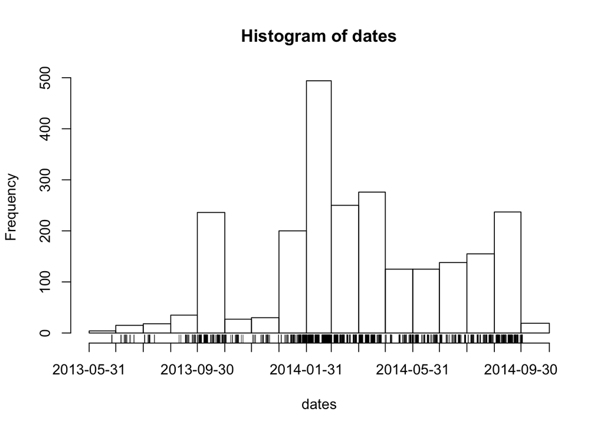

```r
hist(dates, "month", freq = TRUE)
rug(dates)
```

## Summary

The primary R functions for dealing with regular expressions are

- `grep`, `grepl`: Search for matches of a regular expression/pattern in a character vector
- `regexpr`, `gregexpr`: Search a character vector for regular expression matches and return the indices where the match begins; useful in conjunction with regmatches
- `sub`, `gsub`: Search a character vector for regular expression matches and replace that match with another string
- `regexec`: Gives you indices of parethensized sub-expressions.